# M3_T2_CUST_BRAND

Salami Zainab Omobukola

02/07/2024

#LOADING LIBRARIES

```r
library(readr)
library(plyr)
library(dplyr)
library(ggplot2)
library(caret)
library(gbm)
library(pls)
library(C50)
library(randomForest)
library(ipred)
library(e1071)
library(adabag)
library(STAT)
library(rFerns)
library(ranger)
```

# 1 INTRODUCTION

Blackwell Electronics recently conducted a survey to understand the brand preferences of their customers, with the goal of determining which of two computer brands their customers prefer. This information is crucial for Blackwell Electronics as it will guide their strategic relationship with the computer manufacturers. However, not all survey responses captured the brand preference data.

To address this issue, we aim to predict the missing brand preference data using customer responses to other survey questions such as salary, age, and other demographic information. This project involves applying and optimizing two decision tree classification methods in R: C5.0 and RandomForest. By comparing the performance of these classifiers, we will determine which method is more effective for predicting brand preference.

The data set labeled CompleteResponses.csv, containing approximately 10,000 fully answered surveys, will be used to train and validate our models. The SurveyIncomplete.csv data set, which contains incomplete survey responses, will be used to apply the trained model and predict the missing brand preferences.

The final goal is to provide a comprehensive analysis and prediction of brand preferences to Blackwell Electronics’ sales team, helping them make informed strategic decisions.

## 1.1 TO KNOW THE MODELS WE HAVE AT OUR DISPOSAL

```r
available_models <- modelLookup()
```

# 2 LOADING DATASET

```r
DF<-read.csv('CompleteResponses.csv')
SIC <- read.csv('SurveyIncomplete.csv')
```

## 2.1 Displaying the attributes of DF

```r
# attributes(DF)
```

## 2.2 Summary statistics of DF

```r
summary(DF)
```

```
##      salary            age            elevel           car
##  Min.   : 20000   Min.   :20.00   Min.   :0.000   Min.   : 1.00
##  1st Qu.: 52082   1st Qu.:35.00   1st Qu.:1.000   1st Qu.: 6.00
##  Median : 84950   Median :50.00   Median :2.000   Median :11.00
##  Mean   : 84871   Mean   :49.78   Mean   :1.983   Mean   :10.52
##  3rd Qu.:117162   3rd Qu.:65.00   3rd Qu.:3.000   3rd Qu.:15.75
##  Max.   :150000   Max.   :80.00   Max.   :4.000   Max.   :20.00
##     zipcode          credit           brand
##  Min.   :0.000   Min.   :     0   Min.   :0.0000
##  1st Qu.:2.000   1st Qu.:120807   1st Qu.:0.0000
##  Median :4.000   Median :250607   Median :1.0000
##  Mean   :4.041   Mean   :249176   Mean   :0.6217
##  3rd Qu.:6.000   3rd Qu.:374640   3rd Qu.:1.0000
##  Max.   :8.000   Max.   :500000   Max.   :1.0000
```

## 2.3 Structure of DF

```r
str(DF)
```

```
## 'data.frame':    9898 obs. of  7 variables:
##  $ salary : num  119807 106880 78021 63690 50874 ...
##  $ age    : int  45 63 23 51 20 56 24 62 29 41 ...
##  $ elevel : int  0 1 0 3 3 3 4 3 4 1 ...
##  $ car    : int  14 11 15 6 14 14 8 3 17 5 ...
##  $ zipcode: int  4 6 2 5 4 3 5 0 0 4 ...
##  $ credit : num  442038 45007 48795 40889 352951 ...
##  $ brand  : int  0 1 0 1 0 1 1 1 0 1 ...
```

## 2.4 Names of columns in DF

```r
names(DF)
```

```
## [1] "salary"  "age"     "elevel"  "car"     "zipcode" "credit"  "brand"
```

# 3 DATA PREPARATION/DATA PREPROCESSING

Check for Duplicates

```r
# Checking for duplicates
Duplicates <- DF[duplicated(DF), ]
```

## 3.1 Checking for missing values

```r
# Checking for missing values
colSums(is.na(DF))
```

```
##  salary     age  elevel     car zipcode  credit   brand
##       0       0       0       0       0       0       0
```

*The result above shows that they’re no missing values

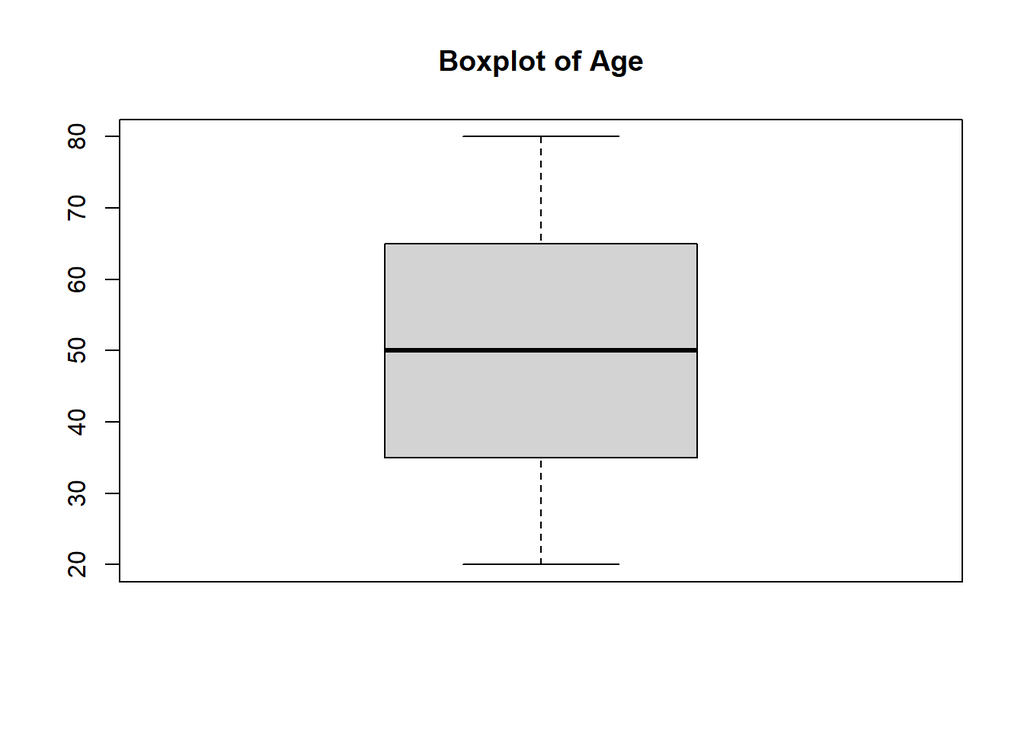

```r
boxplot(DF$age, main = "Boxplot of Age")
```

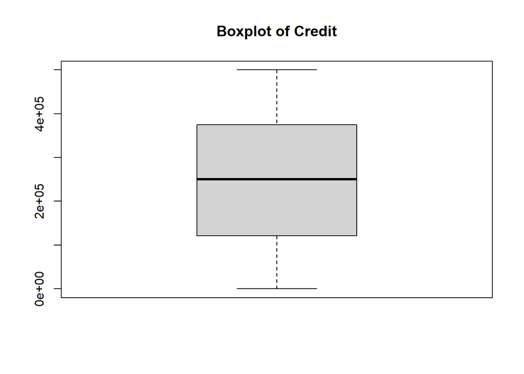

```r
boxplot(DF$credit, main = "Boxplot of Credit")
```

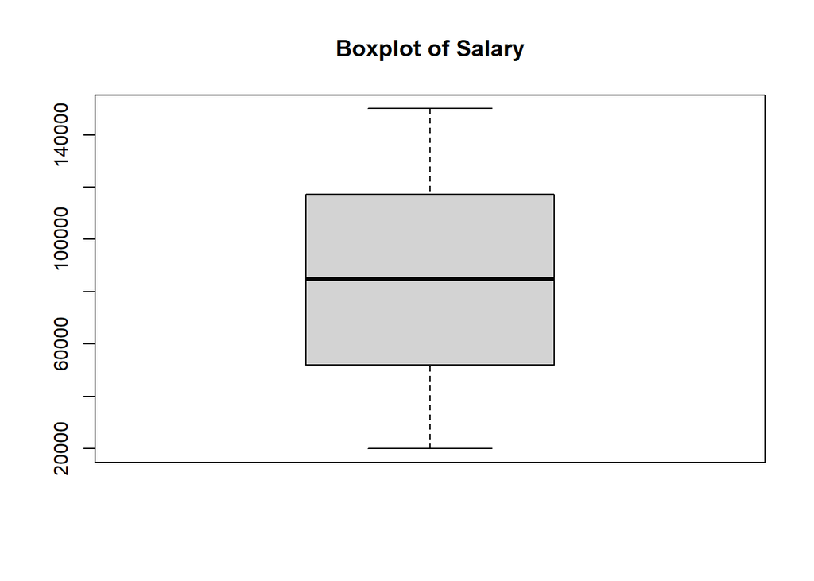

```r
boxplot(DF$salary, main = "Boxplot of Salary")
```

# 4 DATA TRANSFORMATION

*We will convert elevel, car, zipcode, and brand from numerical to categorical for both DF and SIC

```r
DF$elevel<-factor(DF$elevel)
DF$car<-factor(DF$car)
DF$zipcode<-factor(DF$zipcode)
DF$brand<-factor(DF$brand)
```

```r
SIC$elevel<-factor(SIC$elevel)
SIC$car<-factor(SIC$car)
SIC$zipcode<-factor(SIC$zipcode)
SIC$brand<-factor(SIC$brand)
```

## 4.1 Structure of DF after transformation

```r
str(DF)
```

```
## 'data.frame':    9898 obs. of  7 variables:
##  $ salary : num  119807 106880 78021 63690 50874 ...
##  $ age    : int  45 63 23 51 20 56 24 62 29 41 ...
##  $ elevel : Factor w/ 5 levels "0","1","2","3",..: 1 2 1 4 4 4 5 4 5 2 ...
##  $ car    : Factor w/ 20 levels "1","2","3","4",..: 14 11 15 6 14 14 8 3 17 5 ...
##  $ zipcode: Factor w/ 9 levels "0","1","2","3",..: 5 7 3 6 5 4 6 1 1 5 ...
##  $ credit : num  442038 45007 48795 40889 352951 ...
##  $ brand  : Factor w/ 2 levels "0","1": 1 2 1 2 1 2 2 2 1 2 ...
```

## 4.2 Structure of SIC after transformation

```r
str(SIC)
```

```
## 'data.frame':    5000 obs. of  7 variables:
##  $ salary : num  150000 82524 115647 141443 149211 ...
##  $ age    : int  76 51 34 22 56 26 64 50 26 46 ...
##  $ elevel : Factor w/ 5 levels "0","1","2","3",..: 2 2 1 4 1 5 4 4 3 4 ...
##  $ car    : Factor w/ 20 levels "1","2","3","4",..: 3 8 10 18 5 12 1 9 3 18 ...
##  $ zipcode: Factor w/ 9 levels "0","1","2","3",..: 4 4 3 3 4 2 3 1 5 7 ...
##  $ credit : num  377980 141658 360980 282736 215667 ...
##  $ brand  : Factor w/ 2 levels "0","1": 2 1 2 2 2 2 2 2 2 1 ...
```

## 4.3 MAPPING

*MAPPING ALL THE CATEGORICAL VARIABLES ##DF

```r
# Define a named vector for mapping
factor_to_elevel <- c("0" = "Less than High School Degree", "1" = "High School Degree", "2" = "Some College", "3" = "4-year College Degree", "4" = "Master's, Doctoral or Professional Degree")

factor_to_car <- c("1" = "BMW", "2" = "Buick", "3" = "Cadillac", "4" = " Chevrolet", "5" = " Chrysler", "6" = "Dodge", "7" = "Ford", "8" = "Honda", "9" = "Hyundai", "10" = " Jeep", "11" = "Kia", "12" = "Lincoln", "13" = "Mazda", "14" = "Mercedes Benz", "15" = "Mitsubishi", "16" = "Nissan", "17" = "Ram", "18" = "Subaru", "19" = "Toyota", "20" = "None of the above")

factor_to_zipcode <- c("0" = "New England", "1" = "Mid-Atlantic", "2" = "East North Central", "3" = "West North Central", "4" = "South Atlantic", "5" = "East South Central", "6" = "West South Central", "7" = "Mountain", "8" = "Pacific")

factor_to_brand <- c("0" = "Acer", "1" = "Sony")
```

```r
# mapping vector object to the categorical variables
DF$elevel <- factor_to_elevel[DF$elevel]
DF$car <- factor_to_car[DF$car]
DF$zipcode <- factor_to_zipcode[DF$zipcode]
DF$brand <- factor_to_brand[DF$brand]
```

##SIC

```r
# Define a named vector for mapping
factor_to_elevel <- c("0" = "Less than High School Degree", "1" = "High School Degree", "2" = "Some College", "3" = "4-year College Degree", "4" = "Master's, Doctoral or Professional Degree")

factor_to_car <- c("1" = "BMW", "2" = "Buick", "3" = "Cadillac", "4" = " Chevrolet", "5" = " Chrysler", "6" = "Dodge", "7" = "Ford", "8" = "Honda", "9" = "Hyundai", "10" = " Jeep", "11" = "Kia", "12" = "Lincoln", "13" = "Mazda", "14" = "Mercedes Benz", "15" = "Mitsubishi", "16" = "Nissan", "17" = "Ram", "18" = "Subaru", "19" = "Toyota", "20" = "None of the above")

factor_to_zipcode <- c("0" = "New England", "1" = "Mid-Atlantic", "2" = "East North Central", "3" = "West North Central", "4" = "South Atlantic", "5" = "East South Central", "6" = "West South Central", "7" = "Mountain", "8" = "Pacific")

factor_to_brand <- c("0" = "Acer", "1" = "Sony")
```

```r
# mapping vector object to the categorical variables
SIC$elevel <- factor_to_elevel[SIC$elevel]
SIC$car <- factor_to_car[SIC$car]
SIC$zipcode <- factor_to_zipcode[SIC$zipcode]
SIC$brand <- factor_to_brand[SIC$brand]
```

## 4.4 Removing the Brand Column

```r
SIC <- SIC %>% select(-brand)
```

## 4.5 FEATURE ENGINEERING

*Create a new variable age-range using the age attribute for DF and SIC ##DF

```r
DF$age_range <- cut(DF$age, breaks = c(17, 30, 50, 100), labels = c("18-30 Years", "31-50 Years", ">50 Years"))
```

##SIC

```r
SIC$age_range <- cut(SIC$age, breaks = c(17, 30, 50, 100), labels = c("18-30 Years", "31-50 Years", ">50 Years"))
```

# 5 EDA (Exploratory Data Analysis)

## 5.1 Univariance Analysis

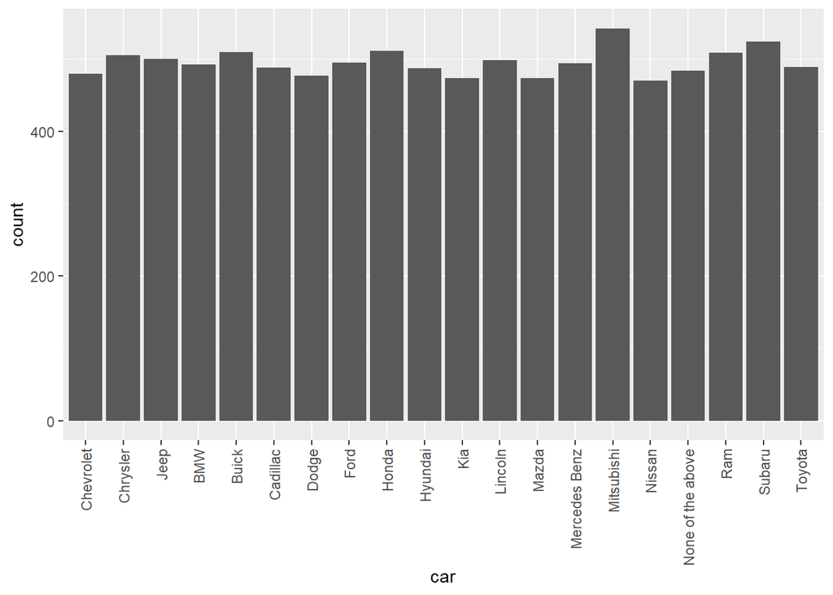

```r
d <- ggplot(DF,aes(car))
d + geom_bar() +
scale_x_discrete(guide = guide_axis(angle = 90))
```

## 5.2 Bivariant Analysis

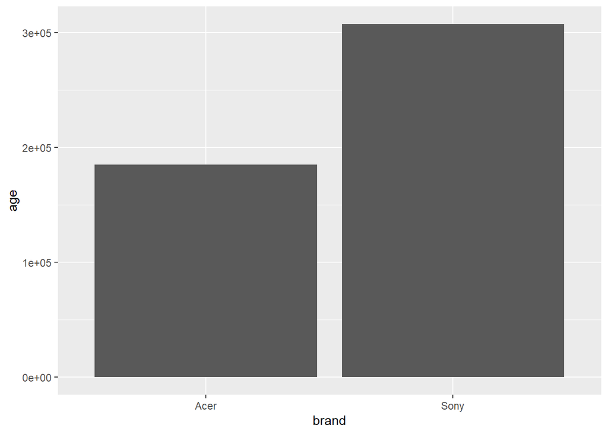

```r
f <- ggplot(DF, aes(brand, age))
f + geom_col()
```

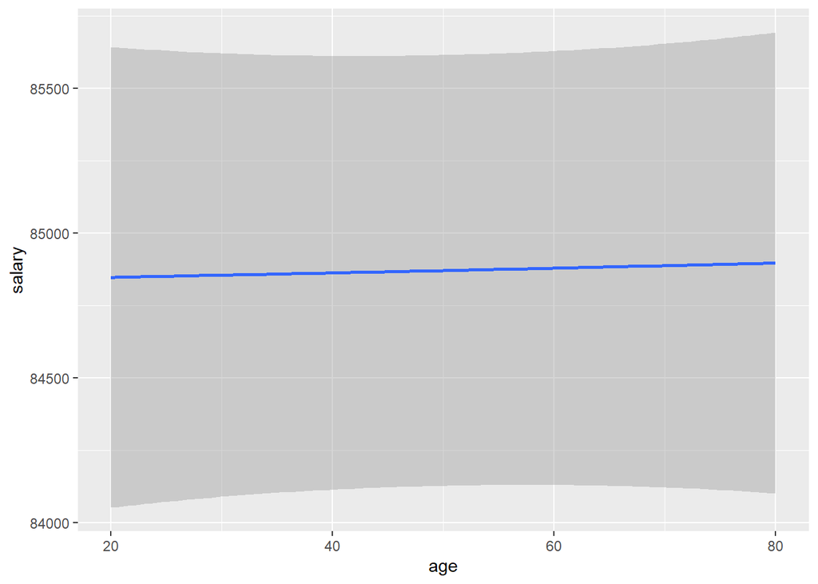

```r
e <- ggplot(DF, aes(age, salary))
e + geom_smooth()
```

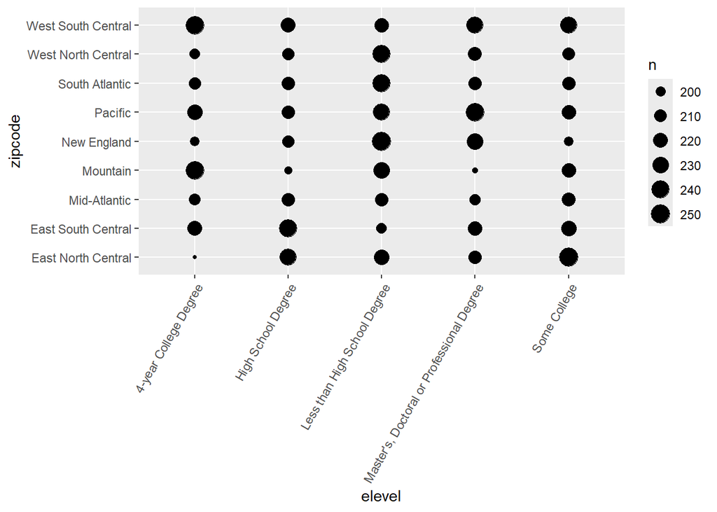

```r
g <- ggplot(DF, aes(elevel, zipcode))
g + geom_count()+
scale_x_discrete(guide = guide_axis(angle = 60))
```

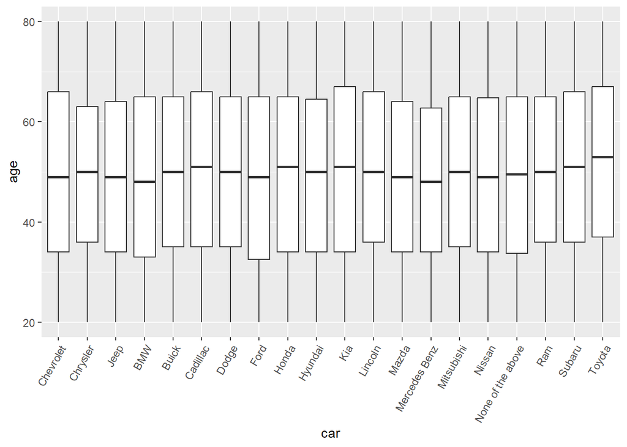

```r
f <- ggplot(DF, aes(car, age))
f + geom_boxplot() +
scale_x_discrete(guide = guide_axis(angle = 60))
```

## 5.3 Multivariate Analysis

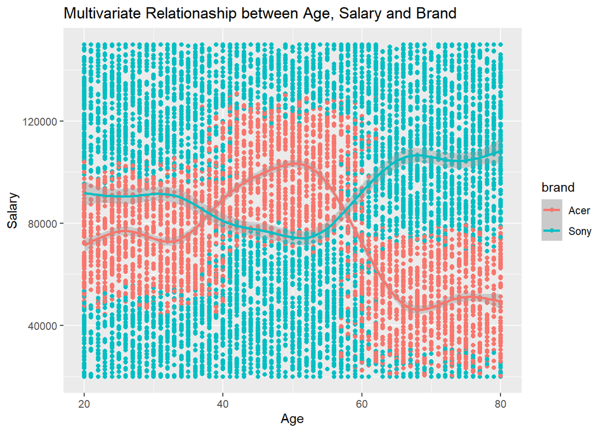

```r
ggplot(DF, aes(x=age, y=salary, col=brand)) +
  geom_point() +
  geom_smooth() +
  labs(x = "Age", y= "Salary", title ="Multivariate Relationaship between Age, Salary and Brand")
```

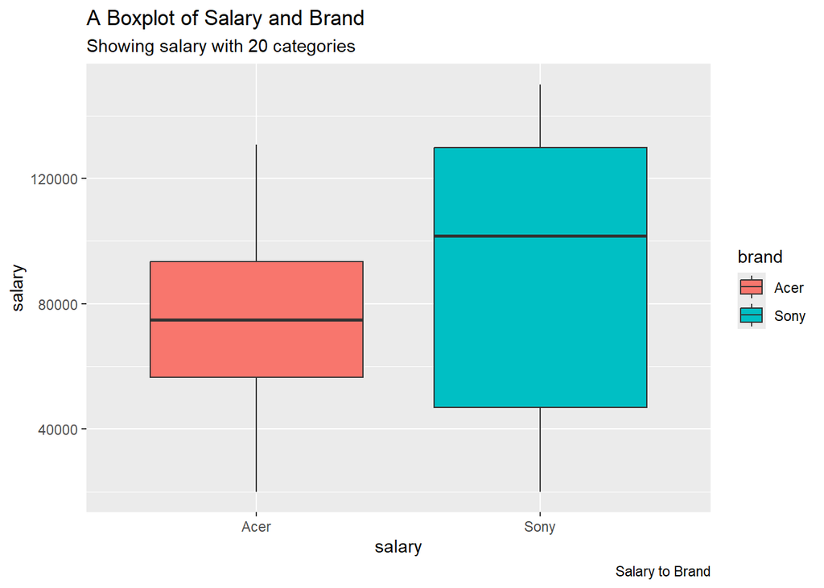

```r
ggplot(DF, aes(x=brand, y=salary, fill=brand)) +
geom_boxplot()+labs(x="salary", title="A Boxplot of Salary and Brand",
subtitle = "Showing salary with 20 categories", caption = "Salary to Brand",
alt = "Salary to brand-Count in frequency")
```

## 5.4 Setting Seed

```r
set.seed(107)
inTrain <- createDataPartition(y = DF$brand, p = .75, list = FALSE)
```

```r
str(inTrain)
```

```
##  int [1:7424, 1] 1 2 3 4 5 6 7 8 9 10 ...
##  - attr(*, "dimnames")=List of 2
##   ..$ : NULL
##   ..$ : chr "Resample1"
```

```r
training <- DF[inTrain, ]
```

```r
testing <- DF[-inTrain, ]
```

```r
nrow(training)
```

```
## [1] 7424
```

```r
nrow(testing)
```

```
## [1] 2474
```

```r
# training
```

# 6 MODELLING

## 6.1 Setting Seed

```r
set.seed(107)
inTrain <- createDataPartition(y = DF$brand, p = .75, list = FALSE)
```

```r
str(inTrain)
```

```
##  int [1:7424, 1] 1 2 3 4 5 6 7 8 9 10 ...
##  - attr(*, "dimnames")=List of 2
##   ..$ : NULL
##   ..$ : chr "Resample1"
```

```r
training <- DF[inTrain, ]
```

```r
testing <- DF[-inTrain, ]
```

```r
nrow(training)
```

```
## [1] 7424
```

```r
nrow(testing)
```

```
## [1] 2474
```

```r
# training
```

## 6.2 Train Control

```r
ctrl <- trainControl(method = 'cv')
```

```r
#plsFit <- train(
  #brand ~ .,
  #data = training,
  #method = "pls",
  #preproc = c("center", "scale")
  #tuneLength = 15,
  #verbose = FALSE,
  ##added
  #trcontrol = ctrl,
  #verbosity = 0
#)
load(file = 'plsFit.rdata')
```

## 6.3 Predicting brand using the plsFit model

```r
pls_brand_predict <- predict(plsFit,testing)
```

```r
str(testing$brand)
```

```
##  chr [1:2474] "Sony" "Sony" "Sony" "Acer" "Sony" "Acer" "Sony" "Sony" ...
```

## 6.4 Ensuring brand in testing set is a factor

```r
testing$brand <- factor(testing$brand)
```

## 6.5 Creating confusion matrix for plsFit predictions

```r
# Creating confusion matrix
pls_CONFUSSION_MATRIX <- confusionMatrix(data=pls_brand_predict, reference = testing$brand)
pls_CONFUSSION_MATRIX
```

```
## Confusion Matrix and Statistics
##
##           Reference
## Prediction Acer Sony
##       Acer   56  118
##       Sony  880 1420
##
##                Accuracy : 0.5966
##                  95% CI : (0.577, 0.616)
##     No Information Rate : 0.6217
##     P-Value [Acc > NIR] : 0.9951
##
##                   Kappa : -0.0201
##
##  Mcnemar's Test P-Value : <2e-16
##
##             Sensitivity : 0.05983
##             Specificity : 0.92328
##          Pos Pred Value : 0.32184
##          Neg Pred Value : 0.61739
##              Prevalence : 0.37833
##          Detection Rate : 0.02264
##    Detection Prevalence : 0.07033
##       Balanced Accuracy : 0.49155
##
##        'Positive' Class : Acer
##
```

## 6.6 Predicting brand using the GBMFit model

```r
#GBMFit <- train
  #brand ~ .,
  #data = training,
  #method = "gbm"
  #preproc = c("center", "scale")
  #tuneLength = 15,
  #verbose = FALSE,
  ##added
  #trcontrol = ctrl,
  #verbosity = 0
load(file = 'GBMFit.rdata')
```

```r
GBM_brand_predict <- predict(GBMFit,testing)
```

## 6.8 Creating confusion matrix for GBMFit predictions

```r
# Creating confusion matrix
GBM_CONFUSSION_MATRIX <- confusionMatrix(data=GBM_brand_predict, reference = testing$brand)
GBM_CONFUSSION_MATRIX
```

```
## Confusion Matrix and Statistics
##
##           Reference
## Prediction Acer Sony
##       Acer  867  105
##       Sony   69 1433
##
##                Accuracy : 0.9297
##                  95% CI : (0.9189, 0.9394)
##     No Information Rate : 0.6217
##     P-Value [Acc > NIR] : < 2e-16
##
##                   Kappa : 0.8516
##
##  Mcnemar's Test P-Value : 0.00797
##
##             Sensitivity : 0.9263
##             Specificity : 0.9317
##          Pos Pred Value : 0.8920
##          Neg Pred Value : 0.9541
##              Prevalence : 0.3783
##          Detection Rate : 0.3504
##    Detection Prevalence : 0.3929
##       Balanced Accuracy : 0.9290
##
##        'Positive' Class : Acer
##
```

## 6.9 Predicting brand using the knnFit model

```r
#knnFit <- train(
  #brand ~ .,
  #data = training,
  #method = "knn"
  #preproc = c("center", "scale")
  #tuneLength = 15,
  #verbose = FALSE,
  ##added
  #trcontrol = ctrl,
  #verbosity = 0
#)
load(file = 'knnFit.rdata')
```

```r
knnFit
```

```
## k-Nearest Neighbors
##
## 7424 samples
##    7 predictor
##    2 classes: 'Acer', 'Sony'
##
## No pre-processing
## Resampling: Bootstrapped (25 reps)
## Summary of sample sizes: 7424, 7424, 7424, 7424, 7424, 7424, ...
## Resampling results across tuning parameters:
##
##   k  Accuracy   Kappa
##   5  0.6541820  0.2618612
##   7  0.6625518  0.2791005
##   9  0.6717335  0.2978986
##
## Accuracy was used to select the optimal model using the largest value.
## The final value used for the model was k = 9.
```

```r
knn_brand_predict <- predict(knnFit,testing)
```

## 6.11 Creating confusion matrix for knnFit predictions

```r
# Creating confusion matrix
knn_CONFUSSION_MATRIX <- confusionMatrix(data=knn_brand_predict, reference = testing$brand)
knn_CONFUSSION_MATRIX
```

```
## Confusion Matrix and Statistics
##
##           Reference
## Prediction Acer Sony
##       Acer  538  324
##       Sony  398 1214
##
##                Accuracy : 0.7082
##                  95% CI : (0.6898, 0.726)
##     No Information Rate : 0.6217
##     P-Value [Acc > NIR] : < 2.2e-16
##
##                   Kappa : 0.3698
##
##  Mcnemar's Test P-Value : 0.006592
##
##             Sensitivity : 0.5748
##             Specificity : 0.7893
##          Pos Pred Value : 0.6241
##          Neg Pred Value : 0.7531
##              Prevalence : 0.3783
##          Detection Rate : 0.2175
##    Detection Prevalence : 0.3484
##       Balanced Accuracy : 0.6821
##
##        'Positive' Class : Acer
##
```

## 6.12 Predicting brand using the c5Fit model

```r
#c5Fit <- train(
  #brand ~ .,
  #data = training,
  #method = "C5.0"
#)
load(file = 'c5Fit.rdata')
```

```r
c5Fit
```

```
## C5.0
##
## 7424 samples
##    7 predictor
##    2 classes: 'Acer', 'Sony'
##
## No pre-processing
## Resampling: Bootstrapped (25 reps)
## Summary of sample sizes: 7424, 7424, 7424, 7424, 7424, 7424, ...
## Resampling results across tuning parameters:
##
##   model  winnow  trials  Accuracy   Kappa
##   rules  FALSE    1      0.8651378  0.7163211
##   rules  FALSE   10      0.9102033  0.8083770
##   rules  FALSE   20      0.9122294  0.8131369
##   rules   TRUE    1      0.8665300  0.7182677
##   rules   TRUE   10      0.9115387  0.8115891
##   rules   TRUE   20      0.9132562  0.8154903
##   tree   FALSE    1      0.8553006  0.6899886
##   tree   FALSE   10      0.9117026  0.8127995
##   tree   FALSE   20      0.9135891  0.8168983
##   tree    TRUE    1      0.8552580  0.6892513
##   tree    TRUE   10      0.9116243  0.8126750
##   tree    TRUE   20      0.9134550  0.8165869
##
## Accuracy was used to select the optimal model using the largest value.
## The final values used for the model were trials = 20, model = tree and winnow
##  = FALSE.
```

```r
c5_brand_predict <- predict(c5Fit,testing)
```

## 6.14 Creating confusion matrix for c5Fit predictions

```r
# Creating confusion matrix
c5_CONFUSSION_MATRIX <- confusionMatrix(data=c5_brand_predict, reference = testing$brand)
c5_CONFUSSION_MATRIX
```

```
## Confusion Matrix and Statistics
##
##           Reference
## Prediction Acer Sony
##       Acer  847   88
##       Sony   89 1450
##
##                Accuracy : 0.9285
##                  95% CI : (0.9176, 0.9383)
##     No Information Rate : 0.6217
##     P-Value [Acc > NIR] : <2e-16
##
##                   Kappa : 0.8479
##
##  Mcnemar's Test P-Value : 1
##
##             Sensitivity : 0.9049
##             Specificity : 0.9428
##          Pos Pred Value : 0.9059
##          Neg Pred Value : 0.9422
##              Prevalence : 0.3783
##          Detection Rate : 0.3424
##    Detection Prevalence : 0.3779
##       Balanced Accuracy : 0.9238
##
##        'Positive' Class : Acer
##
```

## 6.15 Predicting brand using the rFFit model

```r
#rFFit <- train(
#brand ~ .,
#data = training,
#method = "rFerns")
load(file = 'rFFit.rdata')
```

```r
rFFit
```

```
## Random Ferns
##
## 7424 samples
##    7 predictor
##    2 classes: 'Acer', 'Sony'
##
## No pre-processing
## Resampling: Bootstrapped (25 reps)
## Summary of sample sizes: 7424, 7424, 7424, 7424, 7424, 7424, ...
## Resampling results across tuning parameters:
##
##   depth  Accuracy   Kappa
##    1     0.6304749  0.2900476
##    8     0.7012681  0.4146575
##   16     0.7619806  0.5220488
##
## Accuracy was used to select the optimal model using the largest value.
## The final value used for the model was depth = 16.
```

```r
rF_brand_predict <- predict(rFFit,testing)
```

## 6.17 Creating confusion matrix for rFFit predictions

```r
# Creating confusion matrix
rF_CONFUSSION_MATRIX <- confusionMatrix(data=rF_brand_predict, reference = testing$brand)
rF_CONFUSSION_MATRIX
```

```
## Confusion Matrix and Statistics
##
##           Reference
## Prediction Acer Sony
##       Acer  779  372
##       Sony  157 1166
##
##                Accuracy : 0.7862
##                  95% CI : (0.7695, 0.8022)
##     No Information Rate : 0.6217
##     P-Value [Acc > NIR] : < 2.2e-16
##
##                   Kappa : 0.565
##
##  Mcnemar's Test P-Value : < 2.2e-16
##
##             Sensitivity : 0.8323
##             Specificity : 0.7581
##          Pos Pred Value : 0.6768
##          Neg Pred Value : 0.8813
##              Prevalence : 0.3783
##          Detection Rate : 0.3149
##    Detection Prevalence : 0.4652
##       Balanced Accuracy : 0.7952
##
##        'Positive' Class : Acer
##
```

## 6.18 Predicting brand using the rangerFit model

```r
#rangerFit <- train(
#brand ~ .,
#data = training,
#method = "ranger")
load(file = 'rangerFit.rdata')
```

```r
rangerFit
```

```
## Random Forest
##
## 7424 samples
##    7 predictor
##    2 classes: 'Acer', 'Sony'
##
## No pre-processing
## Resampling: Bootstrapped (25 reps)
## Summary of sample sizes: 7424, 7424, 7424, 7424, 7424, 7424, ...
## Resampling results across tuning parameters:
##
##   mtry  splitrule   Accuracy   Kappa
##    2    gini        0.6230108  0.002791149
##    2    extratrees  0.6222477  0.000000000
##   19    gini        0.9163867  0.822355957
##   19    extratrees  0.9135645  0.816261130
##   36    gini        0.9114666  0.811760154
##   36    extratrees  0.9159263  0.821360888
##
## Tuning parameter 'min.node.size' was held constant at a value of 1
## Accuracy was used to select the optimal model using the largest value.
## The final values used for the model were mtry = 19, splitrule = gini
##  and min.node.size = 1.
```

```r
ranger_brand_predict <- predict(rangerFit,testing)
```

## 6.20 Creating confusion matrix for rangerFit predictions

```r
# Creating confusion matrix
ranger_CONFUSSION_MATRIX <- confusionMatrix(data=ranger_brand_predict, reference = testing$brand)
ranger_CONFUSSION_MATRIX
```

```
## Confusion Matrix and Statistics
##
##           Reference
## Prediction Acer Sony
##       Acer  837   75
##       Sony   99 1463
##
##                Accuracy : 0.9297
##                  95% CI : (0.9189, 0.9394)
##     No Information Rate : 0.6217
##     P-Value [Acc > NIR] : < 2e-16
##
##                   Kappa : 0.8497
##
##  Mcnemar's Test P-Value : 0.08122
##
##             Sensitivity : 0.8942
##             Specificity : 0.9512
##          Pos Pred Value : 0.9178
##          Neg Pred Value : 0.9366
##              Prevalence : 0.3783
##          Detection Rate : 0.3383
##    Detection Prevalence : 0.3686
##       Balanced Accuracy : 0.9227
##
##        'Positive' Class : Acer
##
```

## 6.21 RESAMPLING

```r
# RESAMPLING FOR THE BEST PERFORMING MODEL
resamps_Brand <- resamples(list(pls = plsFit, GBM = GBMFit, knn = knnFit, c5 = c5Fit, rFerns = rFFit, ranger = rangerFit))
summary(resamps_Brand)
```

```
##
## Call:
## summary.resamples(object = resamps_Brand)
##
## Models: pls, GBM, knn, c5, rFerns, ranger
## Number of resamples: 25
##
## Accuracy
##             Min.   1st Qu.    Median      Mean   3rd Qu.      Max. NA's
## pls    0.5311594 0.5738412 0.5935673 0.5855954 0.6061818 0.6280664    0
## GBM    0.8994169 0.9071715 0.9135135 0.9125468 0.9155916 0.9272594    0
## knn    0.6529284 0.6644689 0.6718005 0.6717335 0.6766510 0.6926438    0
## c5     0.9071667 0.9094575 0.9130752 0.9135891 0.9166062 0.9233309    0
## rFerns 0.7351648 0.7530554 0.7629953 0.7619806 0.7741341 0.7829803    0
## ranger 0.9084919 0.9120029 0.9155820 0.9163867 0.9204882 0.9276533    0
##
## Kappa
##              Min.     1st Qu.      Median        Mean    3rd Qu.      Max. NA's
## pls    -0.1257530 -0.06175227 -0.03566724 -0.04454077 -0.0213046 0.0000000    0
## GBM     0.7872514  0.80394294  0.81722719  0.81542549  0.8215066 0.8456893    0
## knn     0.2616654  0.28459856  0.29597002  0.29789863  0.3078272 0.3420828    0
## c5      0.8025165  0.80764649  0.81570466  0.81689826  0.8234045 0.8383377    0
## rFerns  0.4682004  0.50798227  0.52540611  0.52204877  0.5429300 0.5623654    0
## ranger  0.8053715  0.81205273  0.82016321  0.82235596  0.8315870 0.8465334    0
```

## 6.22 TUNING GRID

```r
# Define the tuning grid
tuneGrid <- expand.grid(.mtry = 34,
                        .splitrule = "extratrees",
                        .min.node.size = 1)
# Train the model with parameter tuning
rangerFit_Final <- train(
  brand ~ .,
  data = training,
  method = "ranger",
  tuneGrid = tuneGrid,
  trControl = trainControl(method = "cv", number = 5)
)
```

```r
rangerFit_Final
```

```
## Random Forest
##
## 7424 samples
##    7 predictor
##    2 classes: 'Acer', 'Sony'
##
## No pre-processing
## Resampling: Cross-Validated (5 fold)
## Summary of sample sizes: 5939, 5939, 5939, 5940, 5939
## Resampling results:
##
##   Accuracy  Kappa
##   0.917565  0.8248411
##
## Tuning parameter 'mtry' was held constant at a value of 34
## Tuning
##  parameter 'splitrule' was held constant at a value of extratrees
##
## Tuning parameter 'min.node.size' was held constant at a value of 1
```

```r
 ranger_brand_predict_Final <- predict(rangerFit_Final,SIC)
```

```r
ranger_brand_predict_Final
```

[output not shown]

[output cut: 344 more lines]

## 6.23 Combining DataFrames by Columns

```r
# Combine data frames by columns
combined_data <- cbind(SIC, ranger_brand_predict_Final)
```

# 7 RECOMMENDATION

Based on the analysis conducted using the C5.0, Ranger, KNN, GBM and Rferns classification methods, we recommend the following approach for predicting the brand preferences of Blackwell Electronics customers:

Adopt the Ranger Classifier: If the Ranger classifier shows better performance metrics (such as accuracy, precision, recall, and F1 score) compared to the C5.0, KNN, GBM and Rferns classifier, we recommend using Ranger for the final prediction of brand preferences. Ranger typically handles large datasets with higher accuracy and robustness.

Model Optimization and Regular Monitoring: Ensure continuous optimization of the selected model by periodically retraining it with new data to maintain its accuracy and relevance. This is crucial as customer preferences and market dynamics can change over time.

Integration into the Sales Process: Integrate the predictive model into the sales teams workflow. This can be achieved by developing an easy-to-use interface where sales team members can input new customer data and obtain brand preference predictions quickly.

Further Exploration of Additional Features: Consider collecting and incorporating additional features that might improve the model’s accuracy. For example, including behavioral data or more detailed customer feedback can provide deeper insights.

Training and Support: Provide training sessions for the sales team to ensure they understand how to use the model effectively. Continuous support should be available to address any issues or questions that may arise during the initial implementation phase.

# 8 CONCLUSION

Key findings include:

Predictive Accuracy: The chosen model demonstrated high predictive accuracy, indicating that customer responses to survey questions (such as income, age, etc.) are strong indicators of brand preference.

Implementation Feasibility: Integrating the predictive model into the sales teams workflow is feasible and can significantly enhance decision-making processes related to brand preference strategies.

By leveraging the predictive power of the Ranger classifier, Blackwell Electronics can confidently fill in the missing brand preference data from the incomplete surveys. This will enable the company to make informed strategic decisions and strengthen its relationships with computer manufacturers.

The results of this project highlight the potential of using advanced analytics and machine learning to address business challenges and improve decision-making processes.